# Análisis exploratorio de datos

Felipe Tucca Díaz

2022-06-26

### Enlace github: https://github.com/FelipeTucca/Tarea_DiplomadoR

# **Análisis exploratorio de datos sobre la mortalidad en *Salmo salar* a causa de los factores bloom de algas y oxígeno disuelto**

```r
Mortalidad <- read_excel("Mortalidad.xlsx")
```

## **Análisis preliminar de la base de datos**

Un ajuste previo de la información presente en la planilla “**mortalidad.xlsx**” se realizó mediante la transformación de datos con la función as.factor(), luego se generaron dos nuevas columnas llamadas “*Causa* (agrupando los factores”Mort_bloom” y “Mort_OD”) y “*Muertos*” con la función gather(). Finalmente, se filtraron los valores cero con la función filter(). El ajuste en la base de datos permitió generar un nuevo objeto llamado “**Mortalidad1.xlsx**” para un trabajo óptimo de la información y posterior realización de las tareas indicadas en la pauta de trabajo.

```r
summary(Mortalidad)
```

```
##       Nro          centro_id              año            mes
##  Min.   :   1.0   Length:1070        Min.   :2011   Min.   : 1.000
##  1st Qu.: 268.2   Class :character   1st Qu.:2015   1st Qu.: 4.000
##  Median : 535.5   Mode  :character   Median :2019   Median : 6.000
##  Mean   : 535.5                      Mean   :2018   Mean   : 6.379
##  3rd Qu.: 802.8                      3rd Qu.:2021   3rd Qu.: 9.000
##  Max.   :1070.0                      Max.   :2022   Max.   :12.000
##     Semana              Peso_g         Mort_bloom          Mort_OD
##  Length:1070        Min.   :  48.7   Min.   :     0.0   Min.   :     0
##  Class :character   1st Qu.:1845.8   1st Qu.:     0.0   1st Qu.:     6
##  Mode  :character   Median :2997.3   Median :     0.0   Median :    81
##                     Mean   :3029.6   Mean   :  2660.6   Mean   :  1175
##                     3rd Qu.:4251.9   3rd Qu.:    50.8   3rd Qu.:   441
##                     Max.   :6382.3   Max.   :463152.0   Max.   :128053
```

### *Transformación de datos mediante as.factor*

```r
Mortalidad$centro_id <- as.factor(Mortalidad$centro_id)
```

```r
Mortalidad$año <- as.factor(Mortalidad$año)
```

```r
Mortalidad$mes <- as.factor(Mortalidad$mes)
```

```r
Mortalidad$Semana <- as.factor(Mortalidad$Semana)
```

```r
summary(Mortalidad)
```

```
##       Nro           centro_id        año           mes          Semana
##  Min.   :   1.0   CM0890 :100   2021   :322   4      :155   2021-12: 16
##  1st Qu.: 268.2   CM0235 : 98   2019   :259   5      :129   2021-11: 15
##  Median : 535.5   CM0190 : 87   2015   :237   3      :105   2021-13: 14
##  Mean   : 535.5   CM0740 : 87   2017   : 84   10     :105   2015-19: 13
##  3rd Qu.: 802.8   CM0189 : 78   2013   : 70   11     : 97   2015-43: 13
##  Max.   :1070.0   CM0508 : 77   2016   : 47   6      : 92   2021-14: 13
##                   (Other):543   (Other): 51   (Other):387   (Other):986
##      Peso_g         Mort_bloom          Mort_OD
##  Min.   :  48.7   Min.   :     0.0   Min.   :     0
##  1st Qu.:1845.8   1st Qu.:     0.0   1st Qu.:     6
##  Median :2997.3   Median :     0.0   Median :    81
##  Mean   :3029.6   Mean   :  2660.6   Mean   :  1175
##  3rd Qu.:4251.9   3rd Qu.:    50.8   3rd Qu.:   441
##  Max.   :6382.3   Max.   :463152.0   Max.   :128053
##
```

### *Colapso de columnas con la función gather() y filtro de datos con la función filter()*

```r
Mortalidad1 <- gather(Mortalidad,"Causa", "Muertos", 7:8 ) %>% filter(Muertos > 0)
```

```r
summary(Mortalidad1)
```

```
##       Nro           centro_id        año           mes          Semana
##  Min.   :   1.0   CM0890 :127   2019   :350   4      :183   2021-13:  22
##  1st Qu.: 282.8   CM0235 :124   2021   :346   5      :151   2021-12:  21
##  Median : 555.5   CM0740 :108   2015   :257   3      :123   2015-46:  17
##  Mean   : 538.7   CM0508 :100   2017   : 85   10     :115   2021-11:  17
##  3rd Qu.: 784.2   CM0190 : 97   2013   : 78   11     :112   2015-43:  15
##  Max.   :1070.0   CM0189 : 88   2016   : 55   6      :104   2019-13:  15
##                   (Other):580   (Other): 53   (Other):436   (Other):1117
##      Peso_g          Causa              Muertos
##  Min.   :  48.7   Length:1224        Min.   :     1
##  1st Qu.:1927.3   Class :character   1st Qu.:    42
##  Median :3018.0   Mode  :character   Median :   155
##  Mean   :3060.5                      Mean   :  3353
##  3rd Qu.:4251.2                      3rd Qu.:   681
##  Max.   :6382.3                      Max.   :463152
##
```

La columna Causa se transformó a factor mediante la función as.factor().

```r
Mortalidad1$Causa <- as.factor(Mortalidad1$Causa)
```

### *Resumen final de la información*

```r
summary(Mortalidad1)
```

```
##       Nro           centro_id        año           mes          Semana
##  Min.   :   1.0   CM0890 :127   2019   :350   4      :183   2021-13:  22
##  1st Qu.: 282.8   CM0235 :124   2021   :346   5      :151   2021-12:  21
##  Median : 555.5   CM0740 :108   2015   :257   3      :123   2015-46:  17
##  Mean   : 538.7   CM0508 :100   2017   : 85   10     :115   2021-11:  17
##  3rd Qu.: 784.2   CM0190 : 97   2013   : 78   11     :112   2015-43:  15
##  Max.   :1070.0   CM0189 : 88   2016   : 55   6      :104   2019-13:  15
##                   (Other):580   (Other): 53   (Other):436   (Other):1117
##      Peso_g              Causa        Muertos
##  Min.   :  48.7   Mort_bloom:360   Min.   :     1
##  1st Qu.:1927.3   Mort_OD   :864   1st Qu.:    42
##  Median :3018.0                    Median :   155
##  Mean   :3060.5                    Mean   :  3353
##  3rd Qu.:4251.2                    3rd Qu.:   681
##  Max.   :6382.3                    Max.   :463152
##
```

## **Variación de la variable mediante histogramas**

### *Histograma 1*

Debido a que no se logró visualizar de buena manera la información utilizando histograma (ver Histograma peces muertos), se procedió a la transformación logarítmica de la variable mortalidad en *S. salar* para los años comprendidos entre el 2011 al 2022.

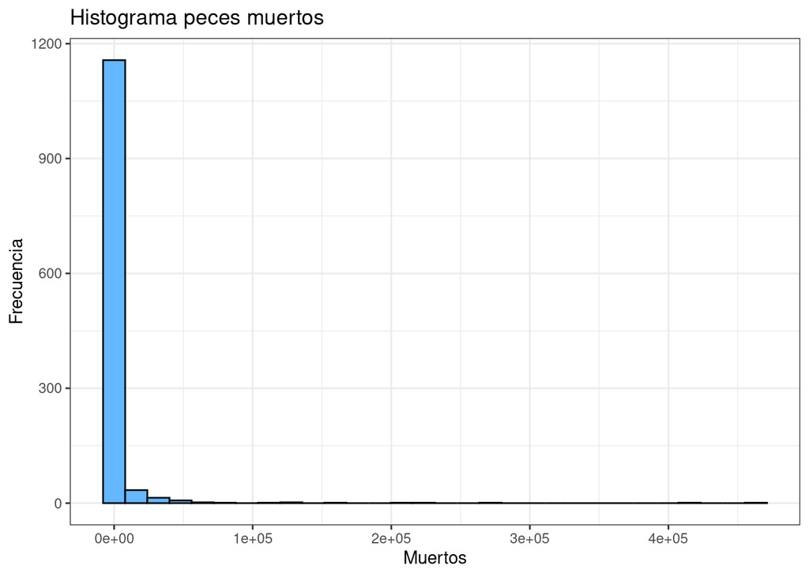

```r
ggplot(Mortalidad1, aes(Muertos)) +
  geom_histogram(bins = 30, color = "black", fill = "steelblue1")+
  labs(title="Histograma peces muertos", x="Muertos", y="Frecuencia") + theme_bw()
```

### *Transformación log con función mutate ()*

#### *Histograma peces muertos*

Al transformar a valores logaritmo la variable muertos se logra una mejor visualización de la información (ver Histograma salmones muertos entre 2011 al 2022).

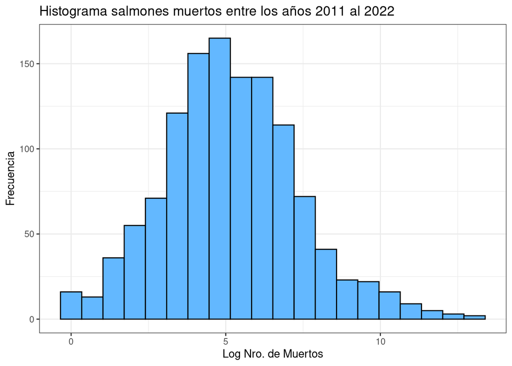

```r
Mortalidad1 %>% mutate(log_Muertos= log(Muertos)) %>% ggplot(aes(log_Muertos)) +
  geom_histogram(bins = 20, color = "black", fill = "steelblue1")+ labs(title="Histograma salmones muertos entre los años 2011 al 2022", x="Log Nro. de Muertos", y="Frecuencia") + theme_bw()
```

#### *Histograma biomasa muerta (toneladas)*

Luego se calculó la biomasa de peces muertos (toneladas), siendo transformada a valores logaritmo para una mejor visualización de la información (ver Histograma biomasa muerta (ton) entre los años 2011 al 2022).

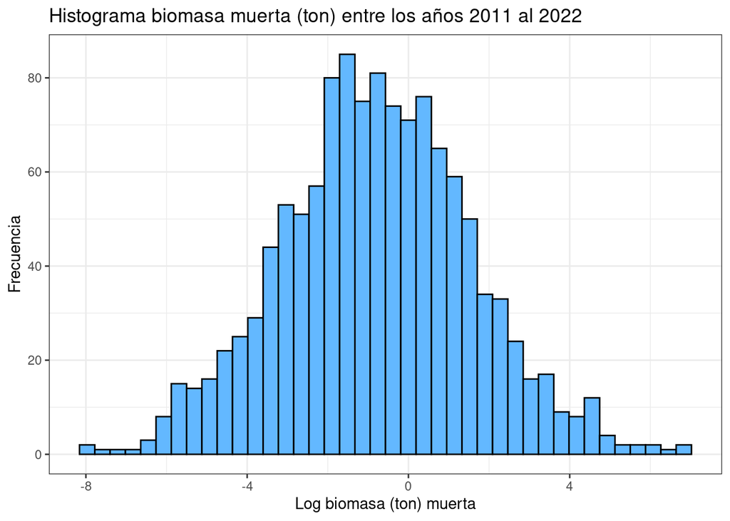

```r
Mortalidad1 %>% mutate(Biomasa_ton= (Peso_g * Muertos)/1000000) %>% mutate(log_biomasa= log(Biomasa_ton)) %>% ggplot(aes(log_biomasa)) +
  geom_histogram(bins = 40, color = "black", fill = "steelblue1")+ labs(title="Histograma biomasa muerta (ton) entre los años 2011 al 2022", x="Log biomasa (ton) muerta", y="Frecuencia") + theme_bw()
```

### *Histograma 2*

Debido a que no se logra visualizar de buena manera la información utilizando histograma se procedió a la transformación logarítmica de la mortalidad en *S. salar* a causa de muertes por bloom de algas y oxígeno disuelto (ver abajo).

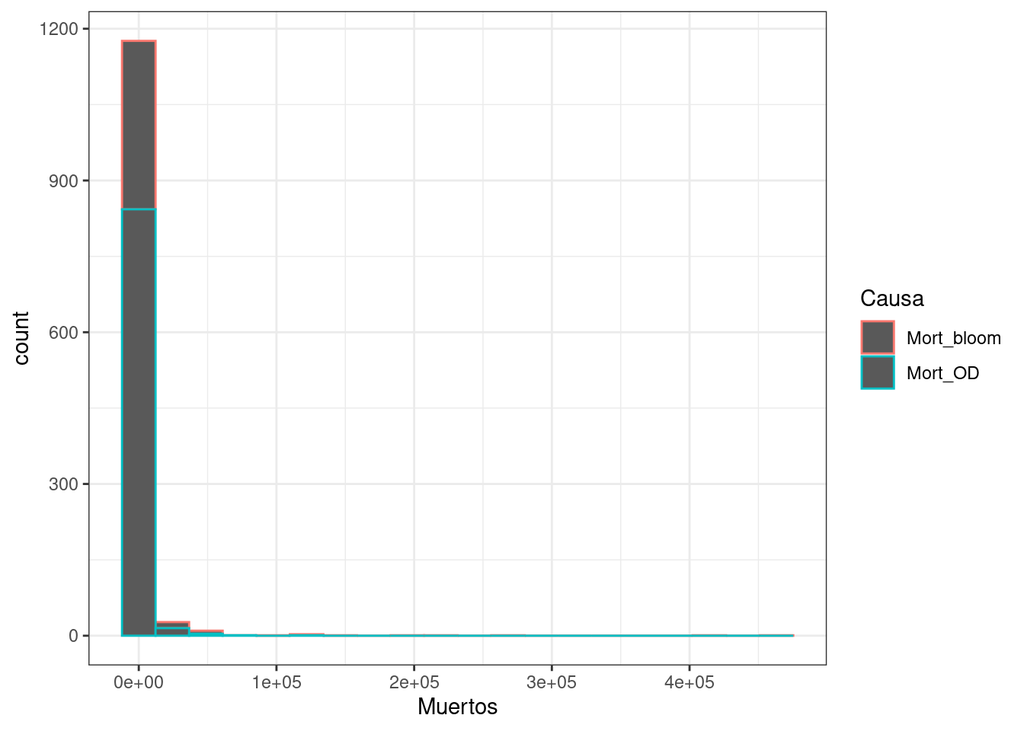

```r
ggplot(Mortalidad1, aes(Muertos))+geom_histogram(bins = 20, aes(color= Causa)) + theme_bw()
```

### *Transformación logarítmica de la variable con función mutate ()*

#### *Histograma log_Muertos y causa de mortalidad*

Datos muestran que históricamente la mayor cantidad de peces muertos es por causa de bloom de algas presentes en la columna de agua.

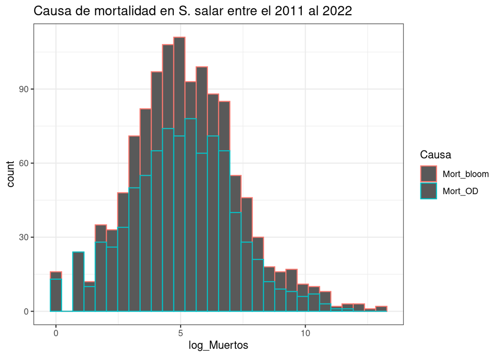

```r
Mortalidad1 %>% mutate(log_Muertos= log(Muertos)) %>% ggplot(aes(log_Muertos))+ geom_histogram(bins = 30, aes(color= Causa)) + labs( title = "Causa de mortalidad en S. salar entre el 2011 al 2022") + theme_bw()
```

#### *Histograma log_Biomasa muerta (toneladas) y causa de mortalidad*

Entre los periodos 2011 a 2022 existe una mayor biomasa muerta (ton) de *S. salar* en el barrio por causa de la acción de bloom de algas que por la disminución de oxígeno disuelto.

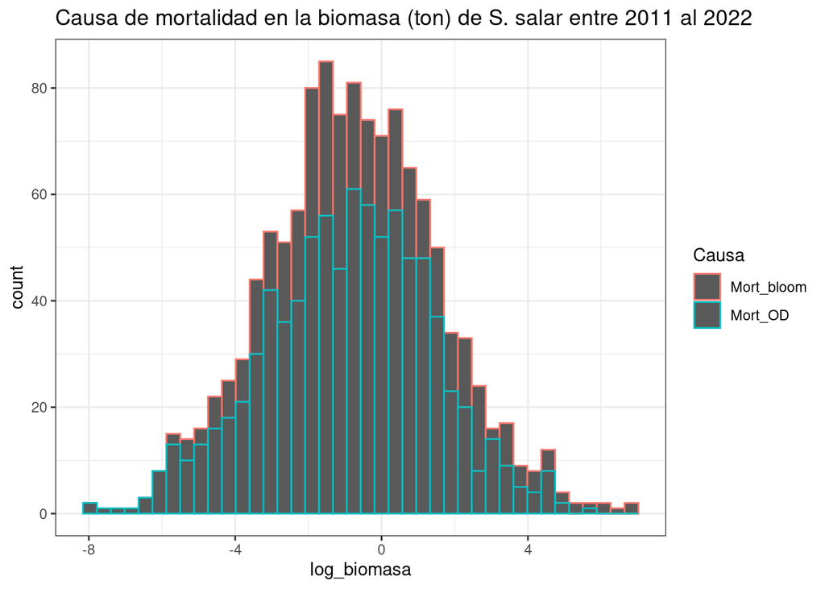

```r
Mortalidad1 %>% mutate(Biomasa_ton= (Peso_g * Muertos)/1000000) %>% mutate(log_biomasa= log(Biomasa_ton)) %>% ggplot(aes(log_biomasa))+ geom_histogram(bins = 40, aes(color= Causa)) + labs( title = "Causa de mortalidad en la biomasa (ton) de S. salar entre 2011 al 2022") + theme_bw()
```

## **Tablas de frecuencia**

Dentro de esta base de datos se observa que la causa de mortalidad en *Salmo salar* para el barrio en estudio durante el periodo 2011 al 2022 **no se encuentra balanceada**, registrándose una mayor frecuencia para la variable oxígeno disuelto (864 registros) que por bloom de algas (360 registros).

```r
table(Mortalidad1$Causa)
```

```
##
## Mort_bloom    Mort_OD
##        360        864
```

```r
table(Mortalidad1$centro_id)
```

```
##
## CM0189 CM0190 CM0196 CM0197 CM0198 CM0199 CM0211 CM0235 CM0252 CM0508 CM0541
##     88     97     73     76     24     76     39    124     18    100      4
## CM0627 CM0642 CM0671 CM0738 CM0740 CM0775 CM0778 CM0890 CM0927 CM0928 CM1122
##     49     22      2     42    108      6     13    127      9     51     75
## CM1519
##      1
```

```r
table(Mortalidad1$año)
```

```
##
## 2011 2012 2013 2014 2015 2016 2017 2018 2019 2020 2021 2022
##   10    1   78   26  257   55   85    2  350   13  346    1
```

```r
table(Mortalidad1$mes)
```

```
##
##   1   2   3   4   5   6   7   8   9  10  11  12
##  61  63 123 183 151 104  89  83  83 115 112  57
```

## **Relación entre variable cuantitativa y factores usando gráficas**

### *Boxplot Causa de la mortalidad en la biomasa (toneladas) de Salmo salar entre el 2011 al 2022*

La biomasa muerta para *S. salar* por causa de bloom de algas ha sido mayor durante los años 2016, 2017 y 2021 en comparasión al oxígeno disuelto, mientras que para los años 2013, 2018, 2019 y 2020 la acción por disminución de oxígeno de disuelto en agua reporta una mayor biomasa muerta (ton) para el barrio en estudio.

En esta gráfica se identificaron **datos faltantes** para la causa de muerte en peces principalmente por bloom de algas (específicamente años 2011, 2012, 2018 y 2022), en cambio, causa de muerte por baja de OD fue la más frecuente en estos últimos 10 años.

**Valores atípicos** principalmente para el registro de biomasa muerta por causa de bloom de algas (años 2013, 2015 y 2019). Mientras que para la causa de muerte por oxígeno (OD) sobre la biomasa de *S. salar* se visualizan valores atípicos para los año 2011, 2019 y 2021. Estos valores atípicos demostraron ser casos puntuales en mortalidades de peces siendo posiblemente relacionado con el periodo y ocurrencia de baja de OD o presencia de bloom de algas. Si bien, es un registro estimado de mortalidad por centro (de acuerdo al peso (g) y número de individuos muertos por diferentes causas temporales de OD y bloom de algas), es probable que existan errores en la toma de datos, pero en base a las ordenes de magnitud existe coherencia de eventos puntuales de mortalidad transformarse en outliers dentro de los registros para el barrio.

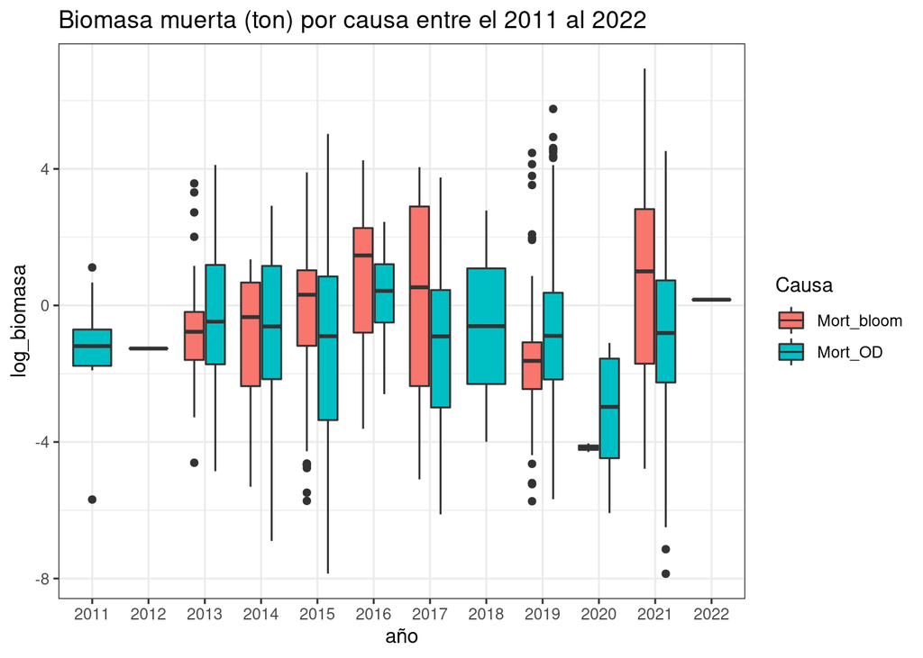

```r
Mortalidad1 %>% mutate(Biomasa_ton= (Peso_g * Muertos)/1000000) %>% mutate(log_biomasa= log(Biomasa_ton)) %>% ggplot(aes(x= año, y= log_biomasa, fill= Causa)) + geom_boxplot() + labs( title = "Biomasa muerta (ton) por causa entre el 2011 al 2022")+ theme_bw()
```

### *Boxplot Causa de mortalidad en S. salar entre los años 2011 al 2022*

Al agrupar los años, la mortalidad en *S. salar* no muestra un patrón que diferencie el tipo de mortalidad entre el periodo 2011 al 2022, siendo la mediana, cuartiles y bigotes similares entre ambos boxplot. No obstante, se observan en esta gráfica valores atípicos para ambas causas de mortalidad, siendo mayores para el caso de mortalidad por la acción de bloom de algas, esto quiere decir que existe un mayor número de peces muertos debido a esta causa dentro del barrio.

Para esta gráfica boxplot donde se compara la causa de muerte, agrupando los años desde el 2011 al 2022, se observan datos atípicos para las muertes por bloom de algas y OD. Mayor cantidad de datos atípicos son reportados para la causa por bloom de algas, probablemente siendo una consecuencia de eventos puntuales de mortalidad en el barrio. En general, los valores atípicos estan inclunados a un mayor número de muertos por ambas causas.

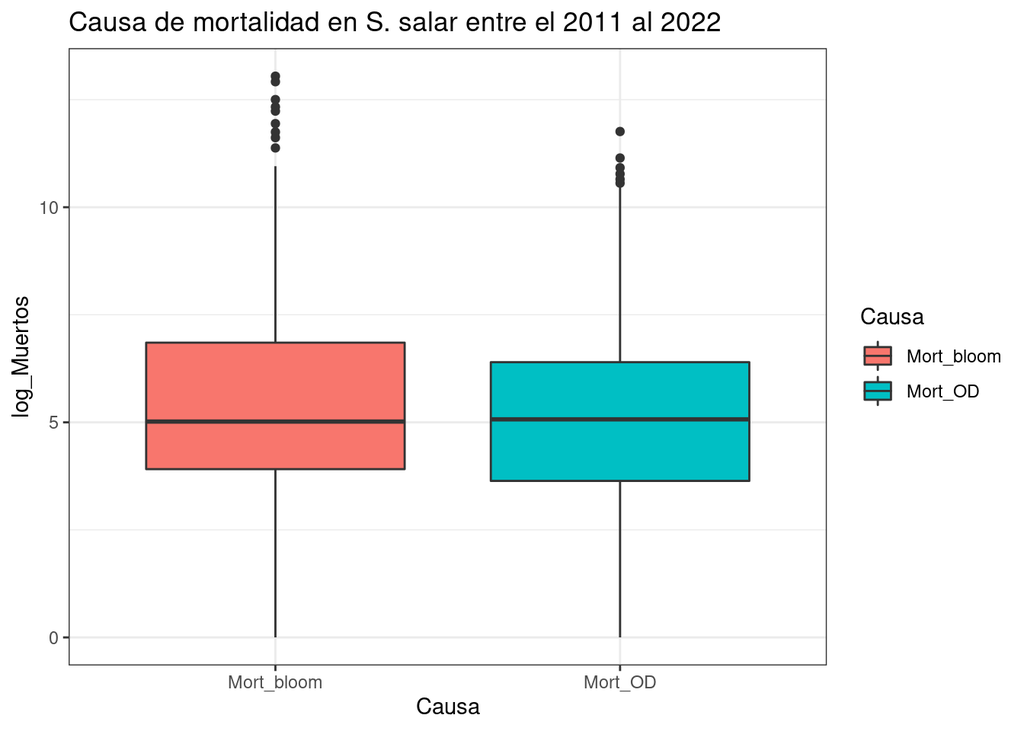

```r
Mortalidad1 %>% mutate(log_Muertos= log(Muertos)) %>% ggplot(aes(x= Causa, y= log_Muertos, fill= Causa)) + geom_boxplot() + labs( title = "Causa de mortalidad en S. salar entre el 2011 al 2022") + theme_bw()
```

### *Relación de variable y factores*

#### *Relación entre las causas de mortalidad por bloom y oxígeno disuelto*

La relación entre las causas de mortalidad por bloom y oxígeno disuelto muestra un patrón de dispersión de la información entre los años 2011 a 2022, sin cumplir un linearidad que relacione directamente la causa de muerte por bloom de algas y el decaimiento del OD.

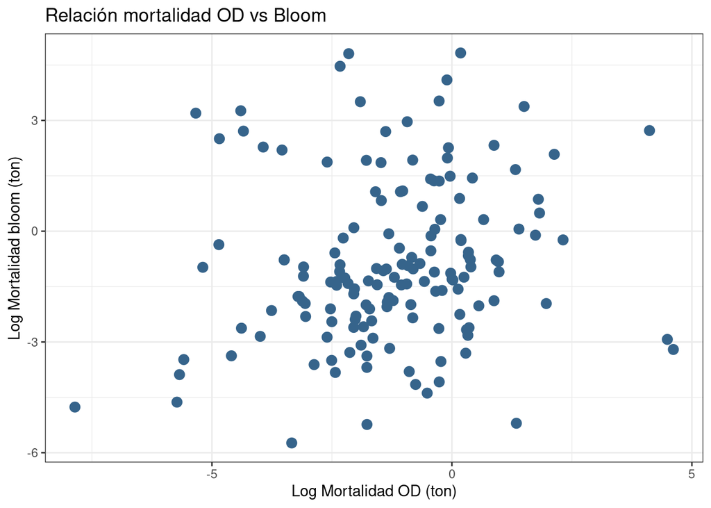

```r
bloom_OD <- Mortalidad %>% filter(Mort_bloom > 0) %>% filter(Mort_OD > 0) %>% mutate(Mort_bloom_ton= (Peso_g * Mort_bloom)/1000000) %>% mutate(log_biomasa_bloom= log(Mort_bloom_ton)) %>% mutate(Mort_OD_ton= (Peso_g * Mort_OD)/1000000) %>% mutate(log_biomasa_OD= log(Mort_OD_ton))

bloom_OD %>% ggplot(aes(x= log_biomasa_OD, y=log_biomasa_bloom))+ geom_point(shape = 19, colour = "steelblue4", size= 3) + labs(x= "Log Mortalidad OD (ton)", y= "Log Mortalidad bloom (ton)")+ theme_gray() + labs( title = "Relación mortalidad OD vs Bloom") + theme_bw()
```

#### *Relación biomasa muerta según el tiempo*

No se observa un patrón claro que diferencie la mortalidad causada por bloom de algas y disminución de oxígeno cuando se analiza la variable temporal por semana y mes para el barrio de estudio entre el periodo 2011 al 2022. Casos puntuales son observados para el mes 4 con una alta biomasa muerta de peces siendo causa principal el bloom de algas (año 2021). En tanto, al analizar por semana la biomasa muerta de *Salmo salar* sólo se observa este aumento de mortalidad por causa de bloom de algas para las semana primeras semans (mes 4) del año 2021, demostrando ser un evento puntual para la causa de mortalidad por bloom.

Al realizar un zoom sobre los registros de mortalidad dentro del año 2021 se oberserva una mayor frecuencia y reporte de mortalidad por causa de OD, sin fluctuar }y presentar registros atípicos de mortalidad por esta causa. Sin embargo, para ese año la mayor biomasa de salmones muertos fue afectada por la acción de bloom de algas, siendo la mayor mortalidad registrada históricamente en este barrio con un log biomasa muerta > 5.

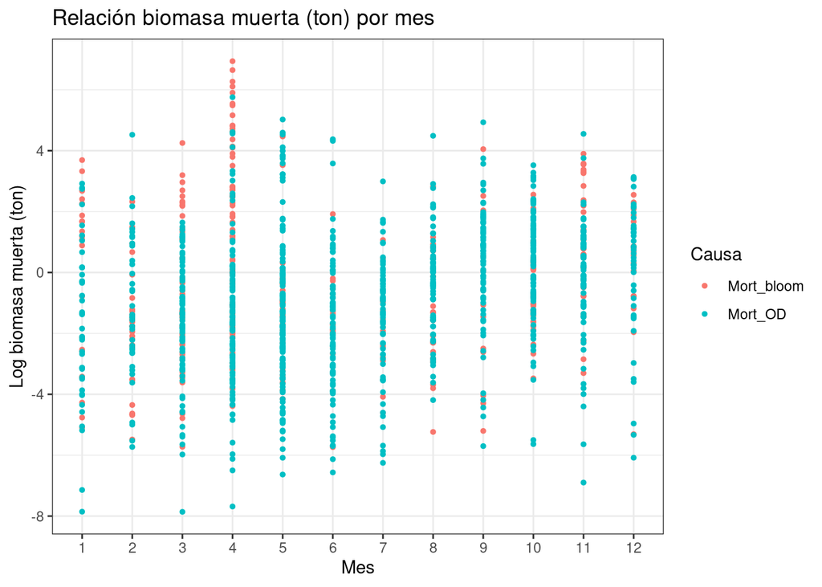

```r
Mortalidad1 %>% mutate(Biomasa_ton= (Peso_g * Muertos)/1000000) %>% mutate(log_biomasa= log(Biomasa_ton)) %>% ggplot(aes(x= mes, y=log_biomasa, color= Causa))+ geom_point(size=1) + labs(x= "Mes", y= "Log biomasa muerta (ton)")+ theme_gray() + labs( title = "Relación biomasa muerta (ton) por mes") + theme_bw()
```

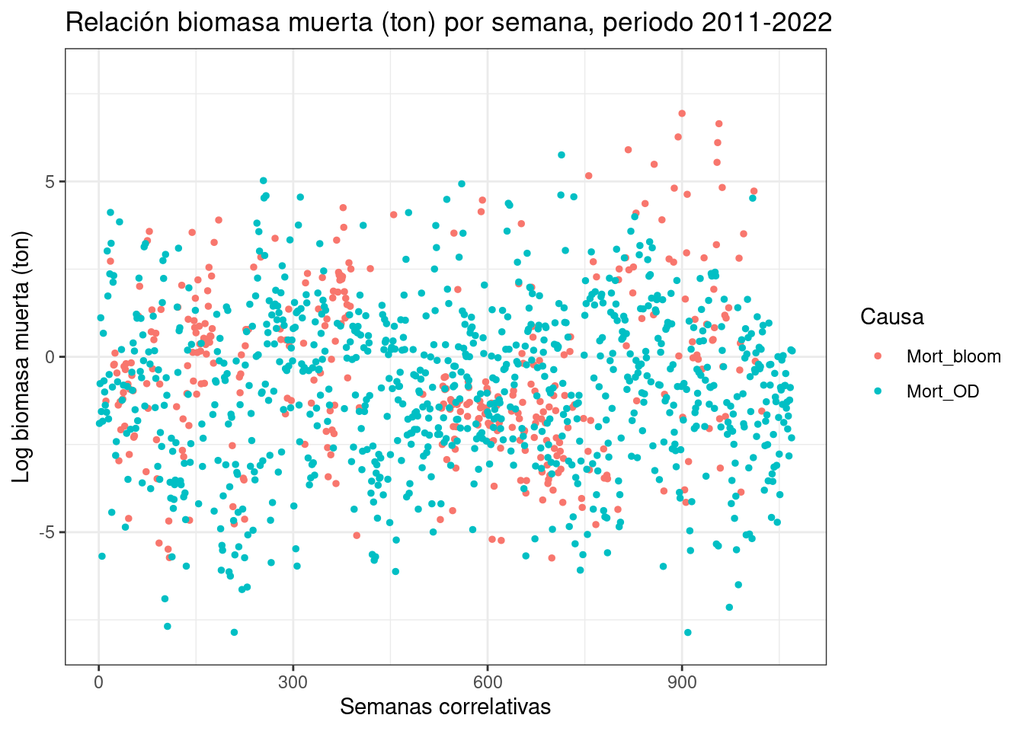

```r
Mortalidad1 %>% mutate(Biomasa_ton= (Peso_g * Muertos)/1000000) %>% mutate(log_biomasa= log(Biomasa_ton)) %>% ggplot(aes(x= Nro, y=log_biomasa, color= Causa))+ geom_point(size=1) + labs(x= "Semanas correlativas", y= "Log biomasa muerta (ton)")+ theme_gray() + labs( title = "Relación biomasa muerta (ton) por semana, periodo 2011-2022") + theme_bw() + scale_y_continuous(limits = c(-8,8))
```

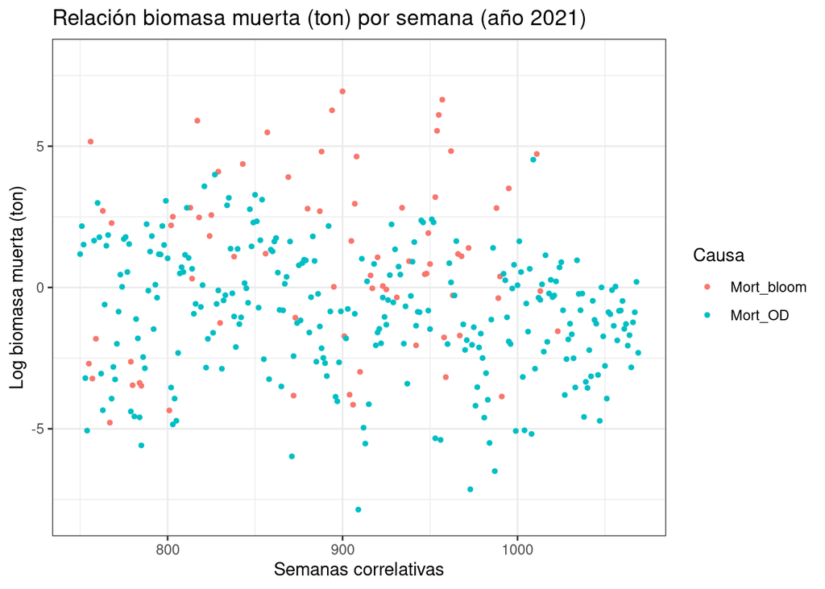

```r
#Zoom para el años 2021
Mortalidad1 %>% mutate(Biomasa_ton= (Peso_g * Muertos)/1000000) %>% mutate(log_biomasa= log(Biomasa_ton)) %>% ggplot(aes(x= Nro, y=log_biomasa, color= Causa))+ geom_point(size=1) + labs(x= "Semanas correlativas", y= "Log biomasa muerta (ton)")+ theme_gray() + labs( title = "Relación biomasa muerta (ton) por semana (año 2021)") + theme_bw() + scale_y_continuous(limits = c(-8,8)) + scale_x_continuous(limits = c(750, 1069))
```

#### *Relación peces muertos y peso entre los años 2011 a 2022*

Salmones de mayor peso (g) registraron un elevado número mortalidades a causa de bloom de algas y oxígeno disuelto durante el periodo 2011 al 2022 para el barrio en estudio.

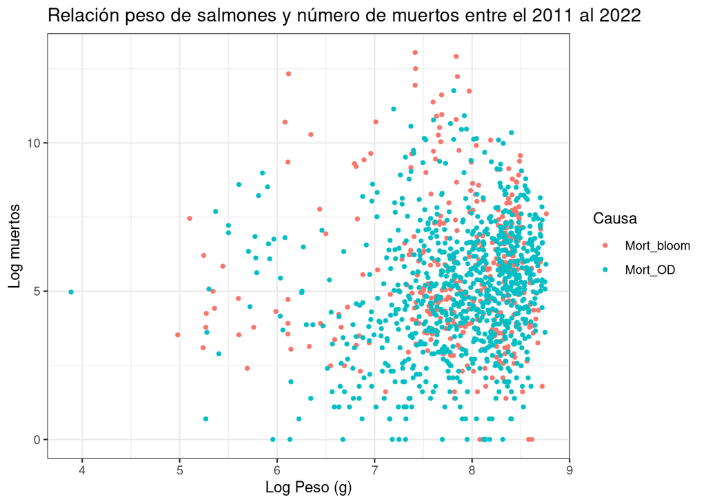

```r
Mortalidad1 %>% mutate(log_peso= log(Peso_g)) %>% mutate(log_muertos= log(Muertos)) %>% ggplot(aes(x= log_peso, y= log_muertos, color=Causa))+ geom_point(size=1) + labs(x= "Log Peso (g)", y= "Log muertos")+ theme_gray() + labs( title = "Relación peso de salmones y número de muertos entre el 2011 al 2022") + theme_bw()
```

## **Resumen de datos mediante tablas y estadística descriptiva**

### *Estadística descriptiva*

La estadística descriptiva muestra que entre los años 2011 al 2022 la biomasa muerta promedio para el barrio en estudio fue de 7.6 toneladas (mediana equivalente a 0.44 ton), alcanzando un máximo de 1031 toneladas de salmones muertos. El registro total de observaciones fue de 1224.

```r
Mortalidad1 %>% mutate(Biomasa_ton= (Peso_g * Muertos)/1000000) %>% summarize(n(), mean(Biomasa_ton), median(Biomasa_ton), max(Biomasa_ton))
```

```
## # A tibble: 1 × 4
##   `n()` `mean(Biomasa_ton)` `median(Biomasa_ton)` `max(Biomasa_ton)`
##   <int>               <dbl>                 <dbl>              <dbl>
## 1  1224                7.63                 0.437              1031.
```

Con respecto al número de salmones muertos para este registro histórico se obtuvo en promedio 3352 peces (mediana 155 muertos), con un rango que va desde 1 a 463152 salmones muertos. El registro total de observaciones fue de 1224.

```r
Mortalidad1 %>% summarize(n(), mean(Muertos), median(Muertos), min(Muertos), max(Muertos))
```

```
## # A tibble: 1 × 5
##   `n()` `mean(Muertos)` `median(Muertos)` `min(Muertos)` `max(Muertos)`
##   <int>           <dbl>             <dbl>          <dbl>          <dbl>
## 1  1224           3353.               155              1         463152
```

Finalmente, en relación al peso del salmon del Atlántico (*S. salar*) muerto en función del tipo de mortalidad (bloom y OD) se obtuvo en promedio los salmones presentaron un peso de 3 kg, con una desviación estándar de 1.5 kg para el periodo comprendido entre los años 2011 al 2022.

```r
Mortalidad1 %>% summarize(n(), mean(Peso_g), sd(Peso_g), median(Peso_g))
```

```
## # A tibble: 1 × 4
##   `n()` `mean(Peso_g)` `sd(Peso_g)` `median(Peso_g)`
##   <int>          <dbl>        <dbl>            <dbl>
## 1  1224          3060.        1480.            3018.
```

## *Tablas*

Debido al alto número de registros históricos (n= 1224) por centro para el barrio en estudio se generó una tabla dinámica mediante la función DT::datatable() lo cual permite realizar búsquedas de información específica dentro de la base de datos *Mortalidad1* (**Tabla 1**).

```r
DT::datatable(Mortalidad1, caption = "Tabla 1. Mortalidad en Salmo salar entre los años 2011 al 2022 según registro por causa (bloom de algas y oxígeno disuelto)")
```

|  | Nro | centro_id | año | mes | Semana | Peso_g | Causa | Muertos |
| --- | --- | --- | --- | --- | --- | --- | --- | --- |
| 1 | 11 | CM0189 | 2012 | 10 | 2012-40 | 164.350000364631 | Mort_bloom | 1722 |
| 2 | 18 | CM0189 | 2013 | 4 | 2013-16 | 1590.51024689186 | Mort_bloom | 9599 |
| 3 | 23 | CM0196 | 2013 | 5 | 2013-18 | 1561.33735910634 | Mort_bloom | 506 |
| 4 | 24 | CM0196 | 2013 | 5 | 2013-19 | 1591.15836096037 | Mort_bloom | 509 |
| 5 | 25 | CM0196 | 2013 | 4 | 2013-17 | 1492.00417321071 | Mort_bloom | 745 |
| 6 | 28 | CM0196 | 2013 | 4 | 2013-16 | 1452.59781883329 | Mort_bloom | 434 |
| 7 | 30 | CM0196 | 2013 | 5 | 2013-22 | 1778.42672095357 | Mort_bloom | 142 |
| 8 | 31 | CM0197 | 2013 | 4 | 2013-15 | 759.400369061385 | Mort_bloom | 68 |
| 9 | 33 | CM0199 | 2013 | 6 | 2013-26 | 2338.09531268645 | Mort_bloom | 119 |
| 10 | 34 | CM0199 | 2013 | 8 | 2013-32 | 2779.54875786019 | Mort_bloom | 45 |

[output cut: 1214 more lines]

Para resumir la biomasa muerta de *S. salar* a causa del bloom de algas y oxígeno disuelto para el barrio en estudio se generó un nuevo objeto llamado *Mortalidad2*. Para este nuevo objeto se realizó estadísitica descriptiva de los datos, calculándose el número de observaciones (23 centros de cultivos en el barrio), promedio de la biomasa muerta (ton), desviación estándar (DE) y los rangos mínimos y máximos de biomasa muerta por centro dentro del barrio.

```r
Mortalidad2 <- Mortalidad1 %>% mutate(Biomasa_ton= (Peso_g * Muertos)/1000000) %>% select(centro_id, Biomasa_ton) %>% group_by(centro_id) %>% summarize("N"= n(), "Promedio"= mean(Biomasa_ton), "DE"= sd(Biomasa_ton), "Mín"= min(Biomasa_ton), "Máx"= max(Biomasa_ton))
```

En base la descripción estadística realizada para el objeto *Mortalidad2* se elaboró una nueva tabla con la función kbl(), la cual resume cada parámetro sobre la biomasa muerta (ton) a causa de los factores bloom y oxígeno disuelto por cada centro presente en el barrio (**Tabla 2**).

```r
kbl(Mortalidad2, caption = "Tabla 2. Resumen de la biomasa muerta (toneladas) para la especie S. salar por cada centro de cultivo presente en el barrio entre los años 2011-2022") %>% kable_classic_2()
```

Tabla 2. Resumen de la biomasa muerta (toneladas) para la especie S. salar por cada centro de cultivo presente en el barrio entre los años 2011-2022

| centro_id | N | Promedio | DE | Mín | Máx |
| --- | --- | --- | --- | --- | --- |
| CM0189 | 88 | 5.7341731 | 19.9491732 | 0.0004599 | 174.536418 |
| CM0190 | 97 | 2.6024764 | 4.9033471 | 0.0037468 | 34.694604 |
| CM0196 | 73 | 8.9422670 | 43.6725885 | 0.0048378 | 366.133600 |
| CM0197 | 76 | 9.6809323 | 30.4637192 | 0.0067651 | 241.859642 |
| CM0198 | 24 | 0.4866976 | 1.0919747 | 0.0019278 | 4.147148 |
| CM0199 | 76 | 1.1985361 | 5.4178787 | 0.0003880 | 46.841966 |
| CM0211 | 39 | 3.2864512 | 8.3540363 | 0.0025398 | 49.648412 |
| CM0235 | 124 | 18.7443777 | 104.7867456 | 0.0033942 | 1031.445184 |
| CM0252 | 18 | 0.3404107 | 0.4991441 | 0.0072560 | 1.832427 |
| CM0508 | 100 | 6.8832638 | 24.5536645 | 0.0003860 | 151.931017 |
| CM0541 | 4 | 1.0045352 | 1.3104791 | 0.0039919 | 2.765078 |
| CM0627 | 49 | 2.6407599 | 4.8802062 | 0.0028311 | 29.304880 |
| CM0642 | 22 | 3.3837127 | 6.3838986 | 0.0662562 | 28.021670 |
| CM0671 | 2 | 8.2599692 | 11.0998314 | 0.4112032 | 16.108735 |
| CM0738 | 42 | 7.7712730 | 17.2828946 | 0.0142186 | 79.541240 |
| CM0740 | 108 | 19.2843706 | 88.7212303 | 0.0025624 | 769.534718 |
| CM0775 | 6 | 1.9822478 | 3.0972013 | 0.0823989 | 8.237503 |
| CM0778 | 13 | 11.2446217 | 34.1849605 | 0.1098314 | 124.883498 |
| CM0890 | 127 | 5.4024318 | 29.8893113 | 0.0007919 | 316.144121 |
| CM0927 | 9 | 2.4964109 | 5.3352173 | 0.0211145 | 16.632674 |
| CM0928 | 51 | 5.3639066 | 20.4483537 | 0.0022820 | 112.730141 |
| CM1122 | 75 | 2.2950041 | 11.3574472 | 0.0035486 | 95.774456 |
| CM1519 | 1 | 2.8343048 | NA | 2.8343048 | 2.834305 |